# Approximate Inference & Bayesian Classification

INFO 521 · Module 5 · Lecture A — Breaking Conjugacy: Logistic Regression & Newton’s Method

Greg Chism

College of Information Science · University of Arizona

August 2026

## Learning outcomes

By the end of Lecture A you should be able to:

1. **Explain why binarizing the outcome breaks conjugacy** — and what dies with it.
2. **State the logistic regression model** and its log-likelihood $\ell(\mathbf{w})$.
3. **Show there is no closed form** — and why that is structural, not bad luck.
4. **Run Newton–Raphson** — gradient, Hessian, update — and read its convergence.

## Part 2 opens here: binarize the outcome

Module 4 closed with everything Gaussian and every formula closed-form. Now ask the *clinical* question instead:

**Is this patient hypertensive?** — $y_n \in \{0, 1\}$ by the ACC/AHA rule (SBP ≥ 130 or DBP ≥ 80; measured BP only, never a feature).

The target is now a **Bernoulli** outcome, not a Gaussian one:

$$p(y_n \mid \mathbf{x}_n, \mathbf{w}) = \mathrm{Bern}\!\left(y_n \,\middle|\, \mu_n\right),
\qquad \mu_n = p(y_n = 1 \mid \mathbf{x}_n).$$

A Gaussian prior on $\mathbf{w}$ meets a **Bernoulli likelihood** — no conjugate pair exists. **The closed-form posterior of Module 4 is gone.** This is the conjugacy-break the course was built around.

## The model: squash the line

Keep the linear score $\mathbf{w}^{\!\top}\mathbf{x}$, then squash it into a probability with the **sigmoid** $\sigma(a) = \dfrac{1}{1 + e^{-a}}$:

$$p(y_n = 1 \mid \mathbf{x}_n, \mathbf{w}) = \sigma\!\left(\mathbf{w}^{\!\top}\mathbf{x}_n\right)$$

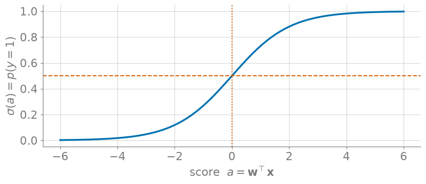

Figure 1: The sigmoid σ(a): linear score in, probability out; σ(0) = ½ is the decision boundary.

- Still **linear in $\mathbf{w}$** inside — basis functions (m1b) still apply.
- **Discriminative**: model $p(y \mid \mathbf{x})$ directly; no model of $\mathbf{x}$.

## The log-likelihood

Bernoulli terms multiply across independent patients; take the log:

$$\ell(\mathbf{w})
= \sum_{n=1}^{N}\Bigl[\, y_n \log \mu_n + (1 - y_n)\log(1 - \mu_n) \Bigr],
\qquad \mu_n = \sigma(\mathbf{w}^{\!\top}\mathbf{x}_n)$$

Set the gradient to zero:

$$\frac{\partial \ell}{\partial \mathbf{w}}
= \mathbf{X}^{\!\top}(\mathbf{y} - \boldsymbol{\mu}) = \mathbf{0}$$

Looks like the normal equations — but $\boldsymbol{\mu}$ hides $\mathbf{w}$ **inside a nonlinearity**. There is no way to isolate $\mathbf{w}$: **no closed form exists.** Not harder algebra — *no* algebra.

## Newton–Raphson: use the curvature

Climb $\ell$ by repeatedly jumping to the peak of its **local quadratic**:

$$\mathbf{w}^{(t+1)}
= \mathbf{w}^{(t)} - \mathbf{H}^{-1}\,
\frac{\partial \ell}{\partial \mathbf{w}}\bigg|_{\mathbf{w}^{(t)}}
\qquad\quad
\mathbf{H} = -\mathbf{X}^{\!\top}\mathbf{R}\,\mathbf{X},
\quad
\mathbf{R} = \mathrm{diag}\bigl(\mu_n(1-\mu_n)\bigr)$$

- **Gradient** says which way is up; the **Hessian** $\mathbf{H}$ says how the slope is changing — one solve per step, no step size to tune.
- $\mathbf{H}$ is **negative definite** ($\mathbf{v}^{\!\top}\mathbf{H}\mathbf{v} < 0\ \forall\,\mathbf{v}\neq\mathbf{0}$): $\ell$ is concave, so the peak Newton finds is **the** peak.
- It is m3b’s uniqueness argument again — $\mathbf{X}^{\!\top}\mathbf{X}$ has become $\mathbf{X}^{\!\top}\mathbf{R}\mathbf{X}$, reweighted by each patient’s uncertainty $\mu_n(1-\mu_n)$.

## Newton on NHANES: five steps to the answer

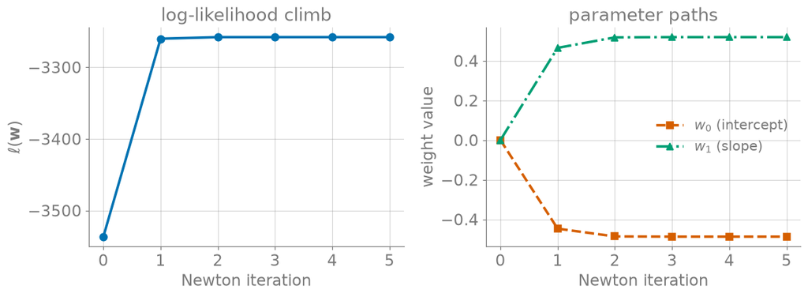

Figure 2: Newton–Raphson on real NHANES (hypertension ~ age): ℓ converges in ~3 steps; ŵ = (−0.49, 0.52) — a per-SD-of-age odds ratio of e^0.52 ≈ 1.7.

## The fitted curve on the data

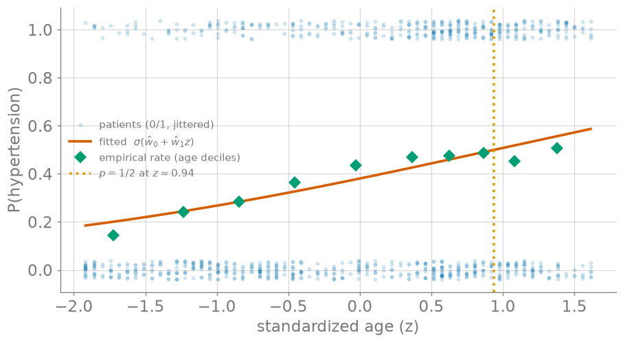

Figure 3: Logistic fit (vermillion) vs. binned empirical rates (green ⋄), real NHANES; jittered 0/1 labels in blue. P(htn) crosses ½ near z ≈ 0.94 (~age 66).

## Live demo: the logistic + Newton explorer

Step Newton by hand in the week04 tool — watch the quadratic model jump and the boundary settle.

## Explorer — static fallback

*The iframe above does not print or export to PDF; this snapshot stands in.*

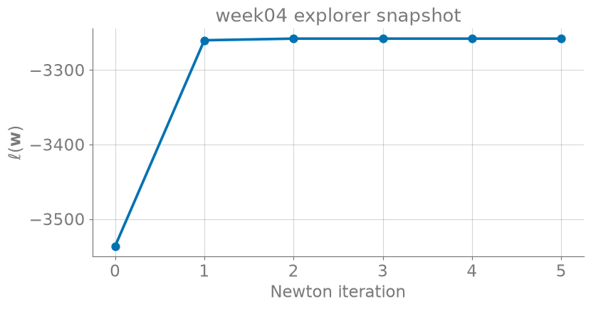

Figure 4: Static fallback: Newton convergence on NHANES (used in print / PDF).

## What we have — and what we lost

**Have** (frequentist story, fully intact):

- $\hat{\mathbf{w}}_{\text{MLE}}$ by Newton; uniqueness via the concave $\ell$; even m3b-style uncertainty from the curvature $-\mathbf{H}^{-1}$ at the peak.

**Lost** (the Bayesian story):

- The **posterior** $p(\mathbf{w} \mid \mathcal{D}) \propto e^{\ell(\mathbf{w})}\, p(\mathbf{w})$ is known only **up to its normalizer** — the evidence integral has no closed form, so credible intervals and honest predictive probabilities are out of reach *exactly*.

Optimization survived binarization. **Integration did not.** Recovering it approximately is Lecture B.

## Recap & bridge

- **Binarize → conjugacy breaks**: Bernoulli likelihood + Gaussian prior has no closed-form posterior — Part 2’s opening move.
- **Logistic regression**: $p(y{=}1\mid\mathbf{x}) = \sigma(\mathbf{w}^{\!\top}\mathbf{x})$; concave $\ell(\mathbf{w})$; gradient $\mathbf{X}^{\!\top}(\mathbf{y}-\boldsymbol{\mu})$.
- **Newton–Raphson**: $\mathbf{w} \leftarrow \mathbf{w} - \mathbf{H}^{-1}\nabla\ell$ — five steps on all of NHANES.

**Next (Lecture B):** approximate the posterior we can’t normalize — a Gaussian at the MAP (Laplace), then samples instead of formulas (Metropolis).